# Multiple Linear Regression Model Design to Predict Oxygen Saturation Levels

Author

Jaden Orli

Published

February 6, 2025

# I. Background

This analysis explores the relationship between oxygen saturation in seawater collected from California’s coastal waters and various physical (ie. depth and temperature) and chemical (ie. salinity and phosphate concentration) variables. This data was collected by the California Collective Oceanic Fisheries Investigations (CalCOFI) which has been conducting these surveys via cruises since 1949 (California Cooperative Oceanic Fisheries Investigations (CalCOFI) 2025). This analysis focuses on designing multiple linear regression models and evaluating their performance to create a final parameterized model.

# II. Load Libraries

Before beginning any analysis, we must load the necessary packages for this analysis. We will also set a seed to ensure future reproducibility.

```r
#clear out the environment
rm(list = ls())

#set the seed for reproducibility
set.seed(42)

#load necessary data packages
library(tidyverse)
library(AICcmodavg)
library(here)
library(kableExtra)
library(equatiomatic)
```

Before moving forward, lets define the independent variable and the various explanatory variables:

```r
#create a dataframe with the variable table outputs
variable_table <- data.frame(Variable = c("Oxygen Saturation", "Temperature", "Salinity", "Depth", "Phosphate Concentration"),
                             Name = c("o2sat", "t_deg_c", "salinity", "depth_m", "po4u_m"),
                             Units = c("% saturation", "Celcius", "practical salinity scale", "meters", "μmoles/L"))

#format the table into a kable
variable_kable <- variable_table %>%
  kable("html",
        caption = htmltools::tags$div(style = "text-align: center; font-size: 20px;",
                                        htmltools::tags$strong("Variable Metadata"))) %>%
  kable_styling(full_width = FALSE, font_size = 14) %>%
  row_spec(row = 0, bold = TRUE) %>%
  kable_classic(html_font = "Times New Roman")

#print the kable
variable_kable
```

**Variable Metadata**

| Variable | Name | Units |
| --- | --- | --- |
| Oxygen Saturation | o2sat | % saturation |
| Temperature | t_deg_c | Celcius |
| Salinity | salinity | practical salinity scale |
| Depth | depth_m | meters |
| Phosphate Concentration | po4u_m | μmoles/L |

# III. Define Functions

Now we can define the functions used throughout the workflow:

## a) Root Mean Square Error

This function can be used to calculate the root mean square error (RMSE) between the actual value and the model predicted by the model. In this analysis, the root mean square error is used within the 10-fold cross validation to “score” each model.

The input is:

- predicted: a vector, column, or value predicted by the model
- actual: a vector, column, or value that is observed or measured from the environment

The output is:

- rmse: the root mean square error

```r
#define a function to calculate the RMSE
rmse <- function(predicted, actual) {

  #calculate the residual sum of squares
  rss <- (predicted - actual)^2

  #calculate the mean square error
  mse <- mean(rss)

  #calculate the root mean square error
  rmse <- sqrt(mse)

  #return the RMSE
  return(rmse)
}
```

## b) K-Fold Cross Validation

This function can be used to calculate the root mean square error (rmse) for the current fold in a k-fold cross validation process.

The input is:

- i: the current fold out of k total folds
- df: the dataframe containing all the observations to be used in the cross validation
- formula: the formula used to create the model
- actual: the name of the independent variable column in the dataframe (df)

The output is:

- rmse: the root mean square error

```r
#define a function to calculate RMSE for a single fold in a k-fold cross validation
kfold_cv <- function(i, df, formula, actual){

  #separate the df into test data
  kfold_test <- df %>%
    filter(group == i) #only select the group corresponding to the current fold iteration

  #separate the df into training data
  kfold_train <- df %>%
    filter(!group == i) #select the groups NOT corresponding to the current fold iteration

  #fit the linear model using the training dataset
  kfold_lm <- lm(formula, kfold_train)

  #get the predictions from the model
  kfold_pred <- kfold_test %>%
    mutate(predicted = predict(kfold_lm, kfold_test)) #generate predictions

  #calculate the root mean square error for the model
  kfold_rmse <- kfold_pred %>%
    summarize(rmse = rmse(predicted, #call on the predicted column
                          kfold_test %>% pull(.data[[actual]]))) #pull the actual column values form the test dataframe

  #return the rmse
  return(kfold_rmse$rmse)

}
```

# IV. Multiple Linear Regression Models

Now we can construct two multiple linear regression models. The two models are outlined below:

$$\begin{aligned}
1.\quad \text{o}_2\text{sat} &= \beta_0 + \beta_1 \cdot \text{t\_deg\_c} + \beta_2 \cdot \text{salinity} + \beta_3 \cdot \text{po4u\_m} + \epsilon \\
2.\quad \text{o}_2\text{sat} &= \beta_0 + \beta_1 \cdot \text{t\_deg\_c} + \beta_2 \cdot \text{salinity} + \beta_3 \cdot \text{po4u\_m} + \beta_4 \cdot \text{depth\_m} + \epsilon
\end{aligned}$$

## a) Read Data

First we will load in the necessary data from CalCOFI and tidy up some of the column names.

```r
#load the necessary data
calcofi <- read_csv(here("task_two", "data", "calcofi_seawater.csv"))

#clean and tidy the data the data
calcofi <- calcofi %>%
  drop_na() %>% #drop any NA's
  rename(o2 = o2sat, #tidy the column names
         temp = t_deg_c,
         depth = depth_m,
         po4 = po4u_m,
         no2 = no2u_m)
```

## b) Model One

The first model predicts oxygen saturation from the temperature, salinity, and phosphate concentration and is forumlated below:

```r
#define the formula for model one
f1 <- o2 ~ temp + salinity + po4

#develop the linear regression model from formula one
model1 <- lm(f1, data = calcofi)
```

## c) Model Two

The second model builds off the first model, and predicts oxygen saturation from temperature, salinity, phosphate concentration, and depth and is formulated below:

```r
#define the formula for model one
f2 <- o2 ~ temp + salinity + depth + po4

#develop the linear regression model from formula one
model2 <- lm(f2, data = calcofi)
```

# V. Model Selection

Now that we have developed the two multiple linear regression models, we will use three different metrics (AIC, BIC, and a 10-fold cross validation) to compare the model’s ability to predict oxygen saturation.

## a) AIC Comparisons

Our first metric for comparison, is the Akaike Information Criterion (AIC) which balances parsimony and fit to prevent underfitting or overfitting the model to the data. The model with the *LOWER* AIC will be determined to be the favored model.

```r
#combine the two linear models into a list
models <- list(model1, model2)

#calculate the AIC for lm1 and lm2
aic <- aictab(cand.set = models,
              modnames = c("Model 1", "Model 2"))
```

## b) BIC Comparisons

Similar to AIC, the Bayesian Information Criterion (BIC) is another metric which can be used to compare model performance. The model with the *LOWER* BIC will be determined to be the favored model.

```r
#calculate the BIC for lm1 and lm2
bic <- bictab(cand.set = models,
              modnames = c("Model 1", "Model 2"))
```

## c) Ten-Fold Cross Validation

Finally, we can use a 10-fold cross validation to better hypertune the model parameters. This method is used to select a model by subsetting the original data into training data and testing data. The training data will be used to estimate the model parameters and then this parameterized model is tested on the testing data. This helps reduce overfitting the model by training and testing the model on different data.

Since we are doing a 10-fold cross validation, this splitting process will be repeated 10 times and each time all of the observations are randomly assigned without replacement to be either part of the training data or the testing data. To compare these models, we will calculate the root mean square error (rmse) for each fold and then calcualte the mean RMSE.

### i) Assigning Data to Folds

The first step of this process is to randomly assign (without replacement) each observation from the CalCOFI data to a fold (ie. each observation is assigned to a group between 1-10). We will then verify that each of the folds has roughly the same number of observations.

```r
#determine the number of folds
total_folds <- 10

#assign an equal number of observations to each fold with the length of the calcofi df
fold_vec <- rep(1:total_folds,
                 length.out = nrow(calcofi))

#randomly assign (without replacement) each observation to a fold
calcofi_fold <- calcofi %>%
  mutate(group = sample(fold_vec, #randomly shuffles the values
                        size = n(),
                        replace = FALSE)) #sample without replacement

#create a table to verify that each fold has roughly the same amount of observations
fold_table <- table(calcofi_fold$group)

#convert the table to a dataframe to use in the kable
fold_df <- as.data.frame(fold_table) %>%
  pivot_wider(names_from = Var1, #pivot wider for an nice format in the final output
              values_from = Freq)

#rename the columns with the fold number
colnames(fold_df) <- paste0("Fold ", colnames(fold_df))

#generate a kable from the wider data
fold_kable <-  fold_df %>%
  kable("html",
        caption = htmltools::tags$div(style = "text-align: center; font-size: 20px;",
                                        htmltools::tags$strong("Fold Observation Distribution"))) %>%
  kable_styling(full_width = FALSE, font_size = 14) %>%
  row_spec(row = 0, bold = TRUE) %>%
  kable_classic(html_font = "Times New Roman")

#print the kable
fold_kable
```

**Fold Observation Distribution**

| Fold 1 | Fold 2 | Fold 3 | Fold 4 | Fold 5 | Fold 6 | Fold 7 | Fold 8 | Fold 9 | Fold 10 |
| --- | --- | --- | --- | --- | --- | --- | --- | --- | --- |
| 10 | 10 | 10 | 10 | 10 | 10 | 10 | 10 | 10 | 10 |

### ii) Perform Cross Validation

Now that we have ensured that there were equal splits in the folds, we can perform the cross validation.

```r
#perform a 10 fold cross validation
rmse_df <- data.frame(fold = 1:total_folds) %>% #create a column called fold with the same number of rows as folds
  mutate(model1_rmse = map_dbl(fold, #the current fold
                               kfold_cv, #call the kfold_cv function
                               df = calcofi_fold, #call the folded dataframe
                               formula = f1, #call the appropriate formula for model1
                               actual = "o2"), #identify the actual values from the o2 column
         model2_rmse = map_dbl(fold, #the current fold
                               kfold_cv, #call the kfold_cv function
                               df = calcofi_fold, #call the folded dataframe
                               formula = f2, #call the appropriate formula for model2
                               actual = "o2")) #identify the actual values from the o2

#return the mean rmse for each model
rmse_means <- rmse_df %>%
  summarize(across(ends_with('rmse'), mean))
```

## d) Compare Methods

Finally, we can compare the various metrics (AIC, BIC, and 10-fold cross validation) to see if they all recommend the same model.

### i) Combine Dataframes

First, we will combine the dataframes:

```r
#create a dataframe from the aic results to be combined with the others
aic_table <- aic %>%
  rename(Model = Modnames, #rename the modnames column
         Value = AICc) %>% #save the AIC values in a Value column
  select(Model, Value) %>% #select the needed columns
  mutate(Method = "AIC") %>%
  mutate(Recommendation = ifelse(Value == min(Value), "Recommended", "Not Recommended")) #create a recommendataion column based on the model with the lowest AIC

#create a dataframe from the bic results to be combined with the others
bic_table <- bic %>%
  rename(Model = Modnames, #rename the modnames column
         Value = BIC) %>% #save the BIC values in a Value column
  select(Model, Value) %>% #select the needed columns
  mutate(Method = "BIC") %>%
  mutate(Recommendation = ifelse(Value == min(Value), "Recommended", "Not Recommended")) #create a recommendataion column based on the model with the lowest BIC

#create a dataframe from the rmse cv results to be combined with the others
rmse_table <- rmse_means %>%
  pivot_longer(cols = ends_with("rmse"), #take the columns that end with rmse
               names_to = "Model", #name the new name column Model
               values_to = "Value") %>% #name the new value column Value
  mutate(Method = "10 Fold CV") %>%
  mutate(Model = ifelse(Model == "model1_rmse", "Model 1", "Model 2")) %>%
  mutate(Recommendation = ifelse(Value == min(Value), "Recommended", "Not Recommended")) #create a recommendataion column based on the model with the lowest RMSE

#combine the three dataframes
combined_table <- bind_rows(rmse_table, aic_table, bic_table) %>%
  arrange(Model) %>% #arrange the order by Model
  mutate(Value = round(Value, 2)) #only keep 2 decimal places for the values
```

### ii) Summary Table

And then we can generate a summary table of the three methods.

```r
#create a kable with the AIC, BIC, and 10-fold cross validation results
combined_kable <- combined_table %>%
  kable("html",
        caption = htmltools::tags$div(style = "text-align: center; font-size: 20px;",
                                        htmltools::tags$strong("Model Comparisons"))) %>%
  kable_styling(full_width = FALSE, font_size = 14) %>%
  row_spec(row = 0, bold = TRUE) %>%
  kable_classic(html_font = "Times New Roman")

#print the kable results
combined_kable
```

**Model Comparisons**

| Model | Value | Method | Recommendation |
| --- | --- | --- | --- |
| Model 1 | 4.98 | 10 Fold CV | Not Recommended |
| Model 1 | 619.03 | AIC | Not Recommended |
| Model 1 | 631.41 | BIC | Not Recommended |
| Model 2 | 4.88 | 10 Fold CV | Recommended |
| Model 2 | 616.60 | AIC | Recommended |
| Model 2 | 631.33 | BIC | Recommended |

# VI. Final Model Selection

All three model selection methods indicate that Model 2 is a better fit model. Now we can print the final parameterized model:

```r
#print the parameterized equation from model two
extract_eq(model2, use_coefs = TRUE, wrap = TRUE)
```

$$\begin{aligned}
\operatorname{\widehat{o2}} &= 144.07 - 0.75(\operatorname{temp}) - 0.44(\operatorname{salinity}) - 0.03(\operatorname{depth})\ - \\
&\quad 37.71(\operatorname{po4})
\end{aligned}$$

Additionally, we can visualize the predictions from model two graphically. In the plot below, the actual oxygen saturation values are shown as an outlined circle and the model predictions are show in **darkslategray4**

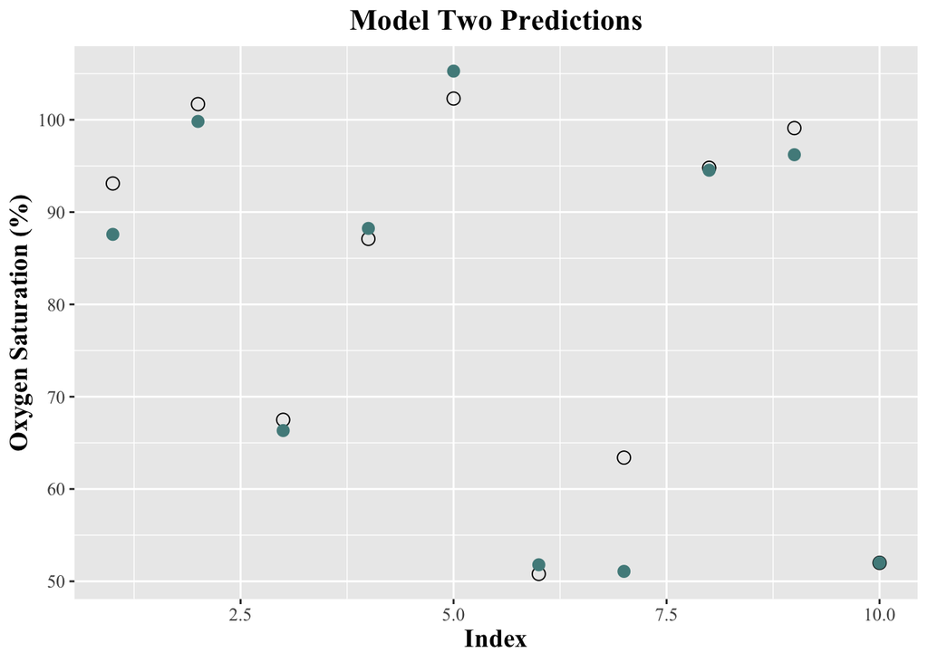

```r
#select 10% of the data to be used as testing data
splitter <- sample(1:nrow(calcofi), size = round(0.1 * nrow(calcofi)), replace = FALSE)

#create a training dataset with 90% of the data
train_data <- calcofi[-splitter, ]

#create a testing dataset with 10% of the data
test_data <- calcofi[splitter, ]

#fit model two with the training data
final_model <- lm(f2, data = train_data)

#generate predicted o2 values from the final model for the test data
test_data$predicted_o2 <- predict(final_model, test_data)

#create the prediction plot from the test data
ggplot(test_data, aes(x = o2, y = predicted_o2)) +
  geom_point(aes(x = seq_along(o2), y = o2), #plot the actual results in black
             shape = 1, size = 3, color = "black") +
  geom_point(aes(x = seq_along(o2), y = predicted_o2), #plot the predicted results
             shape = 16, size = 3, color = "darkslategray4") +
  labs(title = "Model Two Predictions",
       x = "Index",
       y = "Oxygen Saturation (%)") +
  theme(plot.title = element_text(family = "Times New Roman",
                                  face = "bold",
                                  size = 16,
                                  hjust = 0.5),
        axis.title = element_text(family = "Times New Roman",
                                  face = "bold",
                                  size = 14),
        axis.text.x = element_text(family = "Times New Roman",
                                   size = 10),
        axis.text.y = element_text(family = "Times New Roman",
                                   size = 10))
```

## References

California Cooperative Oceanic Fisheries Investigations (CalCOFI). 2025. “CalCOFI Oceanographic Data: Hydrographic and Biological Time-Series of the California Current System.” https://calcofi.org/data/oceanographic-data/bottle-database/.